# Zambia Models

Annalisa Paladino

Import the data and split in train-set and test-set.

```r
library(haven)
data <- read_dta("data/zambia_height92.dta")
head(data)
```

```
## # A tibble: 6 × 11
##   zscore c_gender c_breastf c_age m_agebirth m_height m_bmi m_education m_work
##    <dbl>    <dbl>     <dbl> <dbl>      <dbl>    <dbl> <dbl>       <dbl>  <dbl>
## 1   -159        0         0     4       24.7     149.  21.8           2      0
## 2   -205        0        13    26       22.8     149.  21.8           2      0
## 3   -192        1        18    56       15.3     169.  20.4           2      1
## 4   -146        1         0     6       21.5     162.  22.3           3      0
## 5     69        0         6    54       17.5     162.  22.3           3      0
## 6    -80        0         0     1       30.9     163.  22.9           2      0
## # ℹ 2 more variables: region <dbl>, district <dbl>
```

```r
#split data in train and test set
set.seed(123)
train <- sample(1:nrow(data), 0.85*nrow(data))

test <- setdiff(1:nrow(data), train)

train_data <- data[train,]
test_data <- data[test,]
```

```r
#cast of zscore to integer
train_data$zscore <- as.integer(train_data$zscore)

#factorize gender
train_data$c_gender <- as.factor(train_data$c_gender)

#cast c_breastf as integer
train_data$c_breastf <- as.integer(train_data$c_breastf)

#cast c_age as integer
train_data$c_age <- as.integer(train_data$c_age)

#NOTE: to have the month of birth in m_agebirth calculate: decimal_part * 12

#factorize m_education
train_data$m_education <- as.factor(train_data$m_education)

#factorize m_work
train_data$m_work <- as.factor(train_data$m_work)

#factorize region
train_data$region <- as.factor(train_data$region)

#factorize district
train_data$district <- as.factor(train_data$district)
```

```r
#cast of zscore to integer
test_data$zscore <- as.integer(test_data$zscore)

#factorize gender
test_data$c_gender <- as.factor(test_data$c_gender)

#cast c_breastf as integer
test_data$c_breastf <- as.integer(test_data$c_breastf)

#cast c_age as integer
test_data$c_age <- as.integer(test_data$c_age)

#NOTE: to have the month of birth in m_agebirth calculate: decimal_part * 12

#factorize m_education
test_data$m_education <- as.factor(test_data$m_education)

#factorize m_work
test_data$m_work <- as.factor(test_data$m_work)

#factorize region
test_data$region <- as.factor(test_data$region)

#factorize district
test_data$district <- as.factor(test_data$district)
```

# Linear Regression

```r
fit0 <- lm(zscore ~ ., data = train_data)
summary(fit0)
```

```
##
## Call:
## lm(formula = zscore ~ ., data = train_data)
##
## Residuals:
##     Min      1Q  Median      3Q     Max
## -457.17  -77.52   -2.14   75.00  642.46
##
## Coefficients: (8 not defined because of singularities)
##               Estimate Std. Error t value Pr(>|t|)
## (Intercept)  -968.9270    61.3235 -15.800  < 2e-16 ***
## c_gender1     -14.2796     4.1370  -3.452 0.000563 ***
## c_breastf      -0.4689     0.3495  -1.342 0.179796
## c_age          -1.9309     0.1917 -10.071  < 2e-16 ***
## m_agebirth      0.8764     0.3155   2.778 0.005499 **
## m_height        4.8579     0.3596  13.510  < 2e-16 ***
## m_bmi           3.2776     0.6692   4.898 1.01e-06 ***
## m_education2    8.8505     5.9079   1.498 0.134195
## m_education3   24.9555     7.8043   3.198 0.001397 **
## m_education4   85.2657    17.0128   5.012 5.64e-07 ***
## m_work1        -1.8001     4.5054  -0.400 0.689526
## region2        23.7921    18.8062   1.265 0.205907
## region3       -44.5155    20.7989  -2.140 0.032397 *
## region4       -35.7719    17.5603  -2.037 0.041712 *
## region5         0.6571    13.7390   0.048 0.961858
## region6       -51.6382    19.3335  -2.671 0.007598 **
## region7       -11.0574    22.6660  -0.488 0.625691
## region8       -26.5843    25.3637  -1.048 0.294650
## region9        12.2352    27.9477   0.438 0.661566
## district13    -17.6837    18.4738  -0.957 0.338513
## district14     30.1785    22.7260   1.328 0.184284
## district15     12.4078    21.6117   0.574 0.565918
## district21    -78.4423    33.9318  -2.312 0.020845 *
## district22     33.5808    19.9748   1.681 0.092817 .
## district23     33.6583    23.9744   1.404 0.160424
## district24    -33.2035    25.4652  -1.304 0.192356
## district25    -31.2161    22.1149  -1.412 0.158170
## district26     14.7145    31.1972   0.472 0.637197
## district27     -2.0170    19.9300  -0.101 0.919393
## district28     -9.2358    26.4922  -0.349 0.727392
```

[output cut: 33 more lines]

```
## district89     29.1789    14.0083   2.083 0.037323 *
## district91     19.1189    42.5548   0.449 0.653258
## district92     43.7115    28.1132   1.555 0.120070
## district93     42.7201    25.7583   1.658 0.097302 .
## district94     12.0342    24.6571   0.488 0.625536
## district95     23.5630    27.6050   0.854 0.393396
## district97     27.5198    24.7901   1.110 0.267024
## district98          NA         NA      NA       NA
## district99          NA         NA      NA       NA
## ---
## Signif. codes:  0 '***' 0.001 '**' 0.01 '*' 0.05 '.' 0.1 ' ' 1
##
## Residual standard error: 125.5 on 3693 degrees of freedom
## Multiple R-squared:  0.1967, Adjusted R-squared:  0.183
## F-statistic: 14.35 on 63 and 3693 DF,  p-value: < 2.2e-16
```

By looking at the p-values I can immediately drop m_work and c_breastf since it’s not significant

```r
#vif(fit0)
```

```r
library(Metrics)
predicted <- predict(fit0, test_data)
actual <- test_data$zscore
rmse(predicted, actual)
```

```
## [1] 127.5514
```

```r
fit1 <- lm(zscore ~ c_gender + c_age + m_agebirth + m_height + m_bmi + m_education + region + district, data = train_data)
summary(fit1)
```

```
##
## Call:
## lm(formula = zscore ~ c_gender + c_age + m_agebirth + m_height +
##     m_bmi + m_education + region + district, data = train_data)
##
## Residuals:
##     Min      1Q  Median      3Q     Max
## -457.53  -77.46   -2.38   75.78  640.44
##
## Coefficients: (8 not defined because of singularities)
##               Estimate Std. Error t value Pr(>|t|)
## (Intercept)  -968.2041    61.3145 -15.791  < 2e-16 ***
## c_gender1     -14.2212     4.1357  -3.439 0.000591 ***
## c_age          -2.1327     0.1208 -17.648  < 2e-16 ***
## m_agebirth      0.8667     0.3141   2.759 0.005823 **
## m_height        4.8570     0.3594  13.515  < 2e-16 ***
## m_bmi           3.2408     0.6682   4.850 1.29e-06 ***
## m_education2    8.5765     5.8907   1.456 0.145497
## m_education3   24.4730     7.7635   3.152 0.001633 **
## m_education4   85.5438    16.8323   5.082 3.92e-07 ***
## region2        24.3019    18.7697   1.295 0.195491
## region3       -45.0557    20.7799  -2.168 0.030204 *
## region4       -34.9328    17.5230  -1.994 0.046276 *
## region5         0.8064    13.7202   0.059 0.953134
## region6       -52.6738    19.2732  -2.733 0.006306 **
## region7        -9.5901    22.6413  -0.424 0.671907
## region8       -26.1741    25.3376  -1.033 0.301665
## region9        11.0842    27.9348   0.397 0.691548
## district13    -18.3851    18.4649  -0.996 0.319470
## district14     30.7317    22.7181   1.353 0.176221
## district15     12.2405    21.6092   0.566 0.571124
## district21    -79.3145    33.9258  -2.338 0.019446 *
## district22     34.4049    19.9532   1.724 0.084742 .
## district23     34.0838    23.9683   1.422 0.155100
## district24    -33.1565    25.4614  -1.302 0.192921
## district25    -30.8699    22.1133  -1.396 0.162801
## district26     14.2214    31.1497   0.457 0.648022
## district27     -2.8847    19.9135  -0.145 0.884828
## district28     -8.8134    26.4903  -0.333 0.739376
## district31          NA         NA      NA       NA
```

[output cut: 32 more lines]

```
## district89     29.1279    13.9878   2.082 0.037377 *
## district91     19.7380    42.5477   0.464 0.642746
## district92     43.8507    28.1125   1.560 0.118886
## district93     42.3210    25.7550   1.643 0.100424
## district94     11.5360    24.6544   0.468 0.639876
## district95     23.2292    27.5958   0.842 0.399974
## district97     27.0578    24.7878   1.092 0.275090
## district98          NA         NA      NA       NA
## district99          NA         NA      NA       NA
## ---
## Signif. codes:  0 '***' 0.001 '**' 0.01 '*' 0.05 '.' 0.1 ' ' 1
##
## Residual standard error: 125.5 on 3695 degrees of freedom
## Multiple R-squared:  0.1963, Adjusted R-squared:  0.183
## F-statistic: 14.79 on 61 and 3695 DF,  p-value: < 2.2e-16
```

```r
# vif(fit1)
```

```r
predicted <- predict(fit1, test_data)
actual <- test_data$zscore
rmse(predicted, actual)
```

```
## [1] 127.5348
```

With the help of the stepAIC I try to see if there are other variables that I can drop

```r
require(MASS)
test <- stepAIC(fit0, direction = "both")
```

```
## Start:  AIC=36374.98
## zscore ~ c_gender + c_breastf + c_age + m_agebirth + m_height +
##     m_bmi + m_education + m_work + region + district
##
##
## Step:  AIC=36374.98
## zscore ~ c_gender + c_breastf + c_age + m_agebirth + m_height +
##     m_bmi + m_education + m_work + district
##
##               Df Sum of Sq      RSS   AIC
## - m_work       1      2515 58192709 36373
## - c_breastf    1     28362 58218556 36375
## <none>                     58190193 36375
## - m_agebirth   1    121589 58311783 36381
## - c_gender     1    187727 58377920 36385
## - m_bmi        1    378016 58568209 36397
## - m_education  3    490794 58680987 36401
## - district    53   2390383 60580576 36420
## - c_age        1   1598086 59788280 36475
## - m_height     1   2876120 61066314 36554
##
## Step:  AIC=36373.14
## zscore ~ c_gender + c_breastf + c_age + m_agebirth + m_height +
##     m_bmi + m_education + district
##
##               Df Sum of Sq      RSS   AIC
## - c_breastf    1     28324 58221032 36373
## <none>                     58192709 36373
## + m_work       1      2515 58190193 36375
## - m_agebirth   1    119384 58312093 36379
## - c_gender     1    188631 58381340 36383
## - m_bmi        1    376006 58568715 36395
## - m_education  3    491093 58683802 36399
## - district    53   2454872 60647581 36422
## - c_age        1   1603694 59796402 36473
## - m_height     1   2873632 61066341 36552
##
## Step:  AIC=36372.97
## zscore ~ c_gender + c_age + m_agebirth + m_height + m_bmi + m_education +
##     district
##
##               Df Sum of Sq      RSS   AIC
## <none>                     58221032 36373
## + c_breastf    1     28324 58192709 36373
## + m_work       1      2477 58218556 36375
## - m_agebirth   1    119959 58340991 36379
## - c_gender     1    186312 58407345 36383
## - m_bmi        1    370620 58591652 36395
## - m_education  3    501457 58722489 36399
## - district    53   2464999 60686031 36423
## - m_height     1   2878256 61099289 36552
## - c_age        1   4907268 63128300 36675
```

I can also drop region

```r
fit2 <- lm(zscore ~ c_gender + c_age + m_agebirth + m_height + m_bmi + m_education + district, data = train_data)
summary(fit2)
```

```
##
## Call:
## lm(formula = zscore ~ c_gender + c_age + m_agebirth + m_height +
##     m_bmi + m_education + district, data = train_data)
##
## Residuals:
##     Min      1Q  Median      3Q     Max
## -457.53  -77.46   -2.38   75.78  640.44
##
## Coefficients:
##                Estimate Std. Error t value Pr(>|t|)
## (Intercept)  -1020.8778    60.8014 -16.790  < 2e-16 ***
## c_gender1      -14.2212     4.1357  -3.439 0.000591 ***
## c_age           -2.1327     0.1208 -17.648  < 2e-16 ***
## m_agebirth       0.8667     0.3141   2.759 0.005823 **
## m_height         4.8570     0.3594  13.515  < 2e-16 ***
## m_bmi            3.2408     0.6682   4.850 1.29e-06 ***
## m_education2     8.5765     5.8907   1.456 0.145497
## m_education3    24.4730     7.7635   3.152 0.001633 **
## m_education4    85.5438    16.8323   5.082 3.92e-07 ***
## district13      -0.6441    20.2330  -0.032 0.974604
## district14      30.7317    22.7181   1.353 0.176221
## district15      29.9814    23.1436   1.295 0.195246
## district21     -79.3145    33.9258  -2.338 0.019446 *
## district22      34.4049    19.9532   1.724 0.084742 .
## district23      34.0838    23.9683   1.422 0.155100
## district24     -15.4155    26.7576  -0.576 0.564571
## district25     -30.8699    22.1133  -1.396 0.162801
## district26      21.8394    30.1442   0.724 0.468806
## district27      14.8563    21.5413   0.690 0.490448
## district28      -8.8134    26.4903  -0.333 0.739376
## district31      17.7410    19.4540   0.912 0.361858
## district32      12.5497    25.3721   0.495 0.620893
## district33      -9.4978    39.2099  -0.242 0.808616
## district34      34.8297    23.1057   1.507 0.131792
## district35      -8.3901    22.0323  -0.381 0.703366
## district36       3.3041    21.4826   0.154 0.877774
## district41      65.8179    24.3323   2.705 0.006863 **
## district42      45.2820    20.2009   2.242 0.025048 *
## district43      45.4115    25.9996   1.747 0.080786 .
```

[output cut: 24 more lines]

```
## district89      82.6081    19.4029   4.258 2.12e-05 ***
## district91      46.2377    39.2324   1.179 0.238650
## district92      70.3504    22.8406   3.080 0.002085 **
## district93      68.8207    19.8350   3.470 0.000527 ***
## district94      38.0357    18.3410   2.074 0.038167 *
## district95      49.7289    22.1376   2.246 0.024740 *
## district97      53.5575    18.5416   2.888 0.003893 **
## district98      53.4802    16.2970   3.282 0.001042 **
## district99      26.4997    26.7530   0.991 0.321979
## ---
## Signif. codes:  0 '***' 0.001 '**' 0.01 '*' 0.05 '.' 0.1 ' ' 1
##
## Residual standard error: 125.5 on 3695 degrees of freedom
## Multiple R-squared:  0.1963, Adjusted R-squared:  0.183
## F-statistic: 14.79 on 61 and 3695 DF,  p-value: < 2.2e-16
```

```r
#vif(fit2)
```

```r
predicted <- predict(fit2, test_data)
actual <- test_data$zscore
rmse(predicted, actual)
```

```
## [1] 127.5348
```

```r
fit11 <- lm(zscore ~ c_gender + c_age + m_agebirth + m_height + m_bmi + m_education + region, data = train_data)
summary(fit11)
```

```
##
## Call:
## lm(formula = zscore ~ c_gender + c_age + m_agebirth + m_height +
##     m_bmi + m_education + region, data = train_data)
##
## Residuals:
##     Min      1Q  Median      3Q     Max
## -465.09  -76.79   -2.27   76.41  656.20
##
## Coefficients:
##               Estimate Std. Error t value Pr(>|t|)
## (Intercept)  -980.1131    59.2148 -16.552  < 2e-16 ***
## c_gender1     -13.8062     4.1281  -3.344 0.000833 ***
## c_age          -2.1279     0.1209 -17.605  < 2e-16 ***
## m_agebirth      0.8629     0.3116   2.769 0.005643 **
## m_height        4.8709     0.3557  13.695  < 2e-16 ***
## m_bmi           3.3762     0.6563   5.145 2.82e-07 ***
## m_education2    9.3344     5.6717   1.646 0.099895 .
## m_education3   29.1610     7.4377   3.921 8.99e-05 ***
## m_education4   86.7493    16.6563   5.208 2.01e-07 ***
## region2        10.2947     8.3159   1.238 0.215812
## region3       -26.1700     9.8404  -2.659 0.007860 **
## region4       -35.8947     9.9533  -3.606 0.000315 ***
## region5        11.2586     8.9920   1.252 0.210624
## region6       -39.8332     9.6067  -4.146 3.45e-05 ***
## region7       -23.5353    11.2233  -2.097 0.036061 *
## region8         4.5650     8.8030   0.519 0.604091
## region9       -12.1704    10.6924  -1.138 0.255100
## ---
## Signif. codes:  0 '***' 0.001 '**' 0.01 '*' 0.05 '.' 0.1 ' ' 1
##
## Residual standard error: 126.1 on 3740 degrees of freedom
## Multiple R-squared:  0.179,  Adjusted R-squared:  0.1755
## F-statistic: 50.95 on 16 and 3740 DF,  p-value: < 2.2e-16
```

```r
predicted <- predict(fit11, test_data)
actual <- test_data$zscore
rmse(predicted, actual)
```

```
## [1] 128.5251
```

```r
c(AIC(fit0), AIC(fit1), AIC(fit2), AIC(fit11))
```

```
## [1] 47038.88 47036.87 47036.87 47026.97
```

```r
# check for multicollinearity
#require(car)
#vif(fit11)
```

```r
#library(corrplot)
#correlation matrix for continuous variables
#cor_matrix <- cor(train_data[,c("zscore", "c_breastf", "c_age", "m_agebirth", "m_height", "m_bmi")])
#corrplot(cor_matrix, method = "circle", type = "upper", tl.col = "black", tl.srt = 45)
```

```r
c(AIC(fit0), AIC(fit1), AIC(fit2))
```

```
## [1] 47038.88 47036.87 47036.87
```

I notice that fit2 gives the same results of fit1, this means that the presence of region in my model is not significant, I choose fit2 since it’s the simpler model

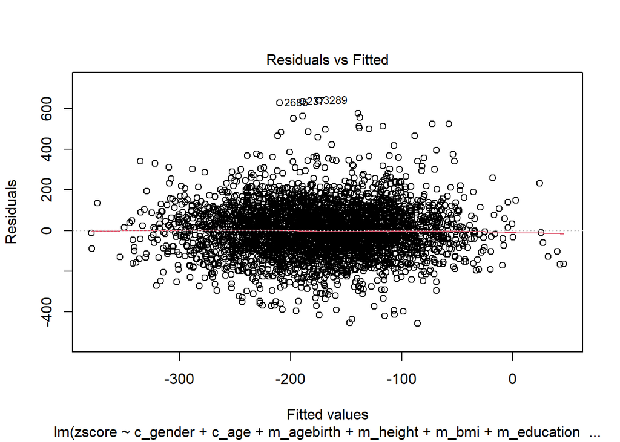

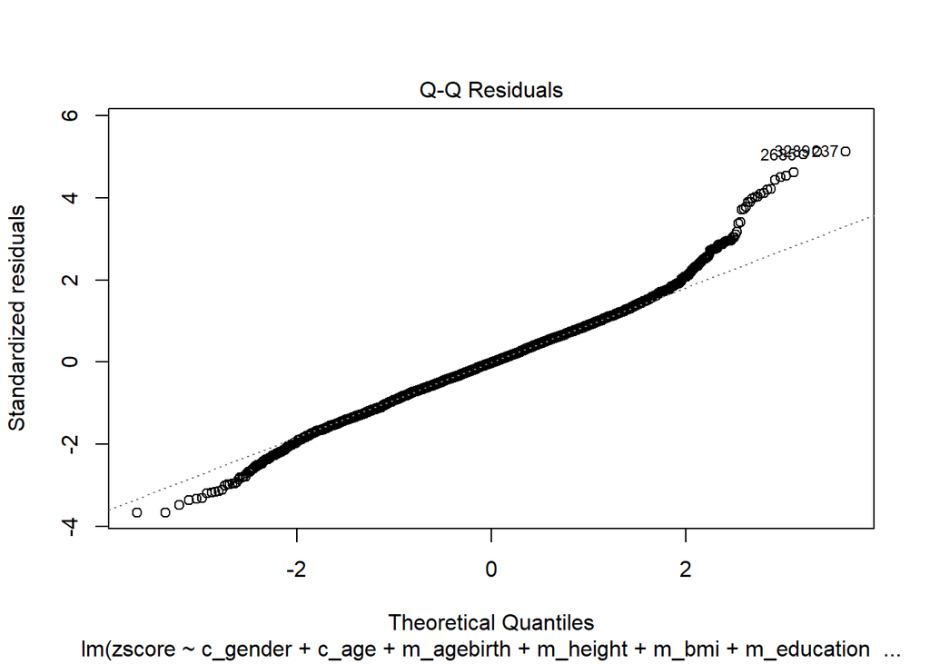

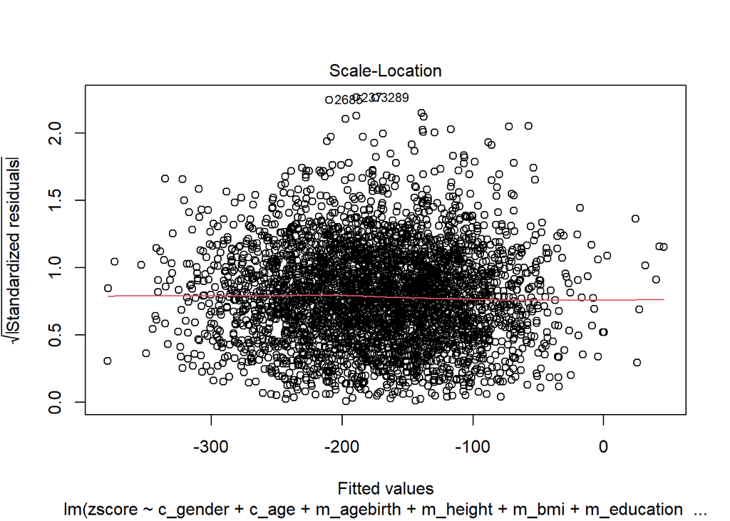

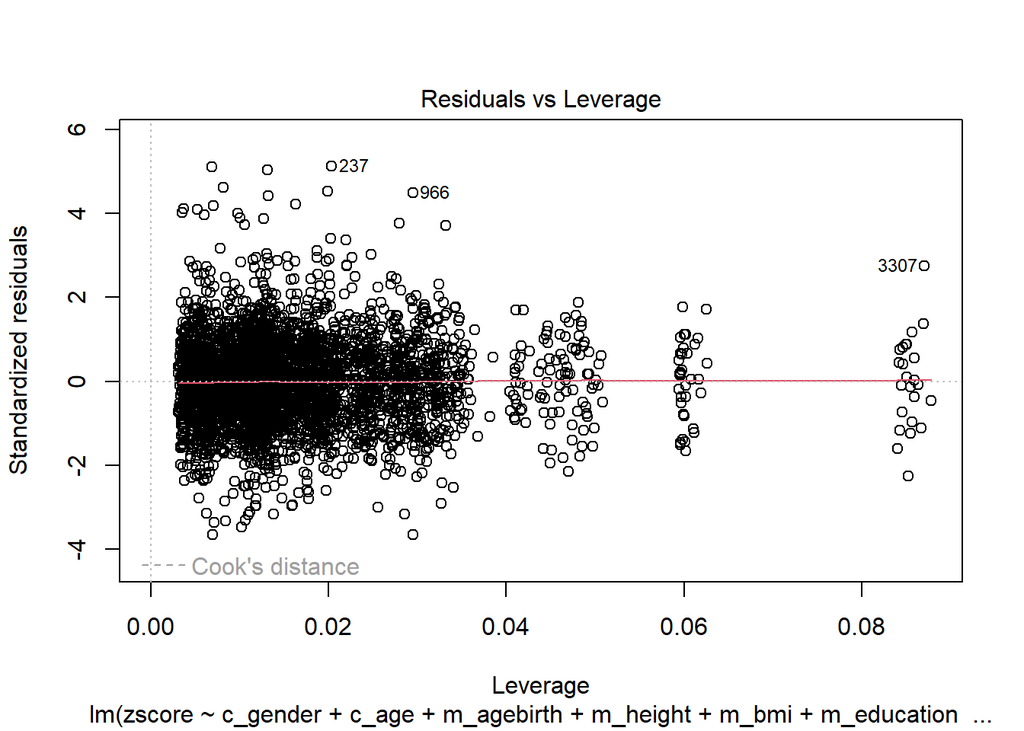

```r
plot(fit2)
```

```r
#clf <- lm(c_breastf ~ c_gender + c_age + m_agebirth + m_height + m_bmi + m_education + district, data = train_data[train_data$c_breastf != 0 & train_data$c_breastf != 1 & train_data$c_breastf != 2 & train_data$c_breastf != 4, ])
```

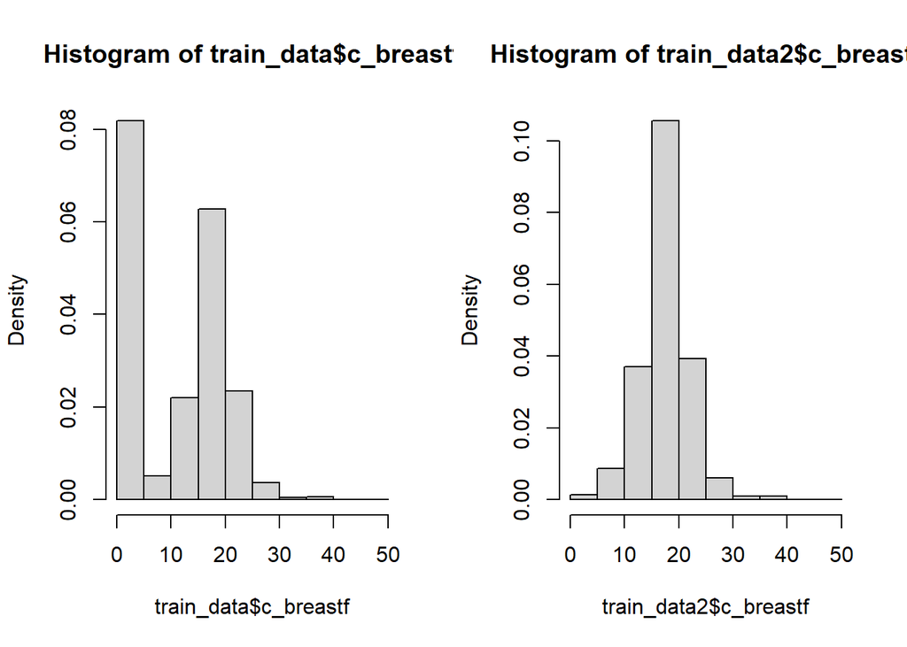

```r
par(mfrow=c(1,2))
hist(train_data$c_breastf, probability = TRUE, breaks = 15)

train_data2 <- train_data[train_data$c_breastf != 0 & train_data$c_breastf != 1 & train_data$c_breastf != 2,] # & train_data$c_breastf != 1 & train_data$c_breastf != 2

hist(train_data2$c_breastf, probability = TRUE, breaks = 15)
```

```r
fit3 <- lm(zscore ~ ., data = train_data2)
summary(fit3)
```

```
##
## Call:
## lm(formula = zscore ~ ., data = train_data2)
##
## Residuals:
##     Min      1Q  Median      3Q     Max
## -460.80  -74.77   -2.27   73.27  665.96
##
## Coefficients: (8 not defined because of singularities)
##                Estimate Std. Error t value Pr(>|t|)
## (Intercept)  -1101.2939    79.6683 -13.823  < 2e-16 ***
## c_gender1      -11.2843     5.3071  -2.126 0.033594 *
## c_breastf       -0.7249     0.6180  -1.173 0.240925
## c_age           -0.4364     0.2241  -1.948 0.051589 .
## m_agebirth       1.4454     0.4058   3.562 0.000376 ***
## m_height         5.2712     0.4558  11.564  < 2e-16 ***
## m_bmi            2.7976     0.8400   3.330 0.000882 ***
## m_education2     9.6480     7.6195   1.266 0.205565
## m_education3    31.3937     9.8731   3.180 0.001495 **
## m_education4   120.2627    22.4287   5.362  9.1e-08 ***
## m_work1         -2.4100     5.7343  -0.420 0.674322
## region2         37.9366    22.7458   1.668 0.095489 .
## region3        -44.7111    25.8665  -1.729 0.084034 .
## region4        -42.5006    22.4688  -1.892 0.058685 .
## region5         -2.6707    17.3213  -0.154 0.877478
## region6        -50.2510    24.3195  -2.066 0.038920 *
## region7         28.2835    33.9009   0.834 0.404204
## region8        -45.3903    34.6440  -1.310 0.190269
## region9         34.5531    34.5655   1.000 0.317596
## district13     -11.9226    23.6893  -0.503 0.614812
## district14      17.6029    30.4158   0.579 0.562822
## district15      13.5743    28.1097   0.483 0.629214
## district21     -99.7955    45.2979  -2.203 0.027693 *
## district22      29.9032    25.1644   1.188 0.234840
## district23      67.9024    30.2637   2.244 0.024953 *
## district24     -22.5419    35.7715  -0.630 0.528655
## district25     -17.4669    28.3439  -0.616 0.537796
## district26      32.9004    39.0543   0.842 0.399641
## district27      17.6861    25.4670   0.694 0.487461
## district28       3.2176    33.9933   0.095 0.924598
```

[output cut: 33 more lines]

```
## district89      32.3699    18.0696   1.791 0.073369 .
## district91      41.0773    59.4220   0.691 0.489463
## district92      86.0239    40.2412   2.138 0.032652 *
## district93      75.2900    35.2651   2.135 0.032875 *
## district94      51.2715    33.6722   1.523 0.127988
## district95      47.6947    37.1942   1.282 0.199869
## district97      70.8589    33.6358   2.107 0.035262 *
## district98           NA         NA      NA       NA
## district99           NA         NA      NA       NA
## ---
## Signif. codes:  0 '***' 0.001 '**' 0.01 '*' 0.05 '.' 0.1 ' ' 1
##
## Residual standard error: 123.5 on 2173 degrees of freedom
## Multiple R-squared:  0.1755, Adjusted R-squared:  0.1516
## F-statistic: 7.344 on 63 and 2173 DF,  p-value: < 2.2e-16
```

```r
predicted <- predict(fit3, test_data[test_data$c_breastf > 2,])
actual <- test_data[test_data$c_breastf > 2,]$zscore
rmse(predicted, actual)
```

```
## [1] 126.7912
```

RMSE decreases, **but we should find a way to consider also children who have been breastfed for 0/1/2 months**, let’s try to transform it in a binary variable.

```r
# Modify c_breasft to be binary, 0 when c_breastf < 2, 1 when c_breastf > 2
library(dplyr)
train_data3 <- train_data %>%
  mutate(c_breastf = ifelse(c_breastf < 2, 0, 1))
test_data3 <- test_data %>%
  mutate(c_breastf = ifelse(c_breastf < 2, 0, 1))
```

```r
fitN <- lm(zscore ~ ., data = train_data3)
summary(fitN)
```

```
##
## Call:
## lm(formula = zscore ~ ., data = train_data3)
##
## Residuals:
##     Min      1Q  Median      3Q     Max
## -445.05  -76.45   -2.06   76.11  647.14
##
## Coefficients: (8 not defined because of singularities)
##               Estimate Std. Error t value Pr(>|t|)
## (Intercept)  -971.9997    61.2377 -15.873  < 2e-16 ***
## c_gender1     -14.3820     4.1306  -3.482 0.000504 ***
## c_breastf     -25.7924     7.1582  -3.603 0.000318 ***
## c_age          -1.5393     0.2037  -7.555 5.24e-14 ***
## m_agebirth      0.8485     0.3151   2.692 0.007125 **
## m_height        4.8772     0.3590  13.584  < 2e-16 ***
## m_bmi           3.3312     0.6683   4.985 6.49e-07 ***
## m_education2    8.5280     5.8988   1.446 0.148345
## m_education3   25.1974     7.7923   3.234 0.001233 **
## m_education4   84.9538    16.9691   5.006 5.81e-07 ***
## m_work1        -2.0526     4.4992  -0.456 0.648260
## region2        24.5505    18.7788   1.307 0.191174
## region3       -44.8101    20.7594  -2.159 0.030950 *
## region4       -34.8411    17.5319  -1.987 0.046963 *
## region5         1.0792    13.7188   0.079 0.937302
## region6       -52.0845    19.3015  -2.698 0.006998 **
## region7       -12.3575    22.6225  -0.546 0.584928
## region8       -28.5879    25.3312  -1.129 0.259155
## region9        12.2955    27.8974   0.441 0.659426
## district13    -18.2489    18.4415  -0.990 0.322458
## district14     30.0307    22.6872   1.324 0.185691
## district15     12.2286    21.5781   0.567 0.570945
## district21    -79.8898    33.8753  -2.358 0.018408 *
## district22     33.4971    19.9419   1.680 0.093094 .
## district23     32.9187    23.9391   1.375 0.169184
## district24    -35.7408    25.4354  -1.405 0.160058
## district25    -30.7866    22.0805  -1.394 0.163315
## district26     14.7045    31.1498   0.472 0.636913
## district27     -2.8064    19.8949  -0.141 0.887828
## district28     -8.4747    26.4508  -0.320 0.748687
```

[output cut: 33 more lines]

```
## district89     28.7406    13.9850   2.055 0.039939 *
## district91     20.3623    42.4906   0.479 0.631810
## district92     44.4522    28.0712   1.584 0.113382
## district93     44.6549    25.7259   1.736 0.082683 .
## district94     14.0754    24.6273   0.572 0.567672
## district95     25.3679    27.5680   0.920 0.357532
## district97     29.7753    24.7618   1.202 0.229260
## district98          NA         NA      NA       NA
## district99          NA         NA      NA       NA
## ---
## Signif. codes:  0 '***' 0.001 '**' 0.01 '*' 0.05 '.' 0.1 ' ' 1
##
## Residual standard error: 125.3 on 3693 degrees of freedom
## Multiple R-squared:  0.1991, Adjusted R-squared:  0.1855
## F-statistic: 14.58 on 63 and 3693 DF,  p-value: < 2.2e-16
```

```r
predicted <- predict(fitN, test_data3)
actual <- test_data3$zscore
rmse(predicted, actual)
```

```
## [1] 127.76
```

```r
c(AIC(fit0), AIC(fit3), AIC(fitN))
```

```
## [1] 47038.88 27961.51 47027.53
```

fit3 has a lower AIC than fit0, this means that fit3 is a better model.

```r
#pred <- predict(fit3, train_data[train_data$c_breastf == 0 | train_data$c_breastf == 1 | train_data$c_breastf == 2 | train_data$c_breastf == 4, ])

#plot(pred, train_data[train_data$c_breastf == 0 | train_data$c_breastf == 1 | train_data$c_breastf == 2 | train_data$c_breastf == 4, ]$zscore)
```

```r
#lf <- lm(c_breastf ~ c_gender + c_age + m_agebirth + m_height + m_bmi + m_education + district, data = train_data[train_data$c_breastf != 0 & train_data$c_breastf != 1 & train_data$c_breastf != 2 ,])
#summary(lf)
```

```r
stepAIC(fit3, direction = "both")
```

```
## Start:  AIC=21611.18
## zscore ~ c_gender + c_breastf + c_age + m_agebirth + m_height +
##     m_bmi + m_education + m_work + region + district
##
##
## Step:  AIC=21611.18
## zscore ~ c_gender + c_breastf + c_age + m_agebirth + m_height +
##     m_bmi + m_education + m_work + district
##
##               Df Sum of Sq      RSS   AIC
## - m_work       1      2694 33149502 21609
## - c_breastf    1     20988 33167796 21611
## <none>                     33146808 21611
## - c_age        1     57862 33204670 21613
## - c_gender     1     68963 33215771 21614
## - m_bmi        1    169196 33316004 21621
## - district    53   1771193 34918001 21622
## - m_agebirth   1    193519 33340326 21622
## - m_education  3    545280 33692087 21642
## - m_height     1   2039723 35186531 21743
##
## Step:  AIC=21609.36
## zscore ~ c_gender + c_breastf + c_age + m_agebirth + m_height +
##     m_bmi + m_education + district
##
##               Df Sum of Sq      RSS   AIC
## - c_breastf    1     21688 33171190 21609
## <none>                     33149502 21609
## + m_work       1      2694 33146808 21611
## - c_age        1     59427 33208929 21611
## - c_gender     1     69419 33218921 21612
## - m_bmi        1    167756 33317258 21619
## - m_agebirth   1    191248 33340750 21620
## - district    53   1794325 34943828 21621
## - m_education  3    545156 33694658 21640
## - m_height     1   2037291 35186793 21741
##
## Step:  AIC=21608.82
## zscore ~ c_gender + c_age + m_agebirth + m_height + m_bmi + m_education +
##     district
##
##               Df Sum of Sq      RSS   AIC
## <none>                     33171190 21609
## + c_breastf    1     21688 33149502 21609
## + m_work       1      3394 33167796 21611
## - c_gender     1     67540 33238730 21611
## - c_age        1     69792 33240982 21612
## - m_bmi        1    168766 33339956 21618
## - m_agebirth   1    182194 33353384 21619
## - district    53   1820013 34991203 21622
## - m_education  3    566478 33737668 21641
## - m_height     1   2057105 35228295 21741
```

```
##
## Call:
## lm(formula = zscore ~ c_gender + c_age + m_agebirth + m_height +
##     m_bmi + m_education + district, data = train_data2)
##
## Coefficients:
##  (Intercept)     c_gender1         c_age    m_agebirth      m_height
##   -1167.5961      -11.1623       -0.4748        1.3944        5.2878
##        m_bmi  m_education2  m_education3  m_education4    district13
##       2.7917        8.8297       30.7553      120.9932       -1.0093
##   district14    district15    district21    district22    district23
##      18.1975       25.8495     -101.9463       31.7636       68.8393
##   district24    district25    district26    district27    district28
##     -11.7317      -15.9991       38.5006       28.2362        5.3815
##   district31    district32    district33    district34    district35
##      11.9116       25.7855      -31.4458       70.4078        3.1350
##   district36    district41    district42    district43    district44
##       1.0891       71.2644       50.5697       31.0165       57.4492
##   district45    district52    district53    district61    district62
##      45.2120       15.9658       75.6359       63.6551      -15.8132
##   district63    district65    district66    district67    district68
##      21.5558       91.9698       38.2798       81.8842       31.7367
##   district69    district71    district72    district73    district74
##      41.5351       37.0074       43.9236        6.7748       51.7033
##   district75    district76    district81    district83    district85
##      65.6717       73.7101      100.6066       41.2408       59.9067
##   district86    district87    district88    district89    district91
##      85.1625       61.7194       52.9880       82.1591       48.4969
##   district92    district93    district94    district95    district97
##      92.8993       82.0708       58.1775       55.1228       78.3184
##   district98    district99
##      50.5549        6.3587
```

```r
fit4 <- lm(zscore ~ c_gender + c_age + m_agebirth + m_height + m_bmi + m_education + district, data = train_data)
summary(fit4)
```

```
##
## Call:
## lm(formula = zscore ~ c_gender + c_age + m_agebirth + m_height +
##     m_bmi + m_education + district, data = train_data)
##
## Residuals:
##     Min      1Q  Median      3Q     Max
## -457.53  -77.46   -2.38   75.78  640.44
##
## Coefficients:
##                Estimate Std. Error t value Pr(>|t|)
## (Intercept)  -1020.8778    60.8014 -16.790  < 2e-16 ***
## c_gender1      -14.2212     4.1357  -3.439 0.000591 ***
## c_age           -2.1327     0.1208 -17.648  < 2e-16 ***
## m_agebirth       0.8667     0.3141   2.759 0.005823 **
## m_height         4.8570     0.3594  13.515  < 2e-16 ***
## m_bmi            3.2408     0.6682   4.850 1.29e-06 ***
## m_education2     8.5765     5.8907   1.456 0.145497
## m_education3    24.4730     7.7635   3.152 0.001633 **
## m_education4    85.5438    16.8323   5.082 3.92e-07 ***
## district13      -0.6441    20.2330  -0.032 0.974604
## district14      30.7317    22.7181   1.353 0.176221
## district15      29.9814    23.1436   1.295 0.195246
## district21     -79.3145    33.9258  -2.338 0.019446 *
## district22      34.4049    19.9532   1.724 0.084742 .
## district23      34.0838    23.9683   1.422 0.155100
## district24     -15.4155    26.7576  -0.576 0.564571
## district25     -30.8699    22.1133  -1.396 0.162801
## district26      21.8394    30.1442   0.724 0.468806
## district27      14.8563    21.5413   0.690 0.490448
## district28      -8.8134    26.4903  -0.333 0.739376
## district31      17.7410    19.4540   0.912 0.361858
## district32      12.5497    25.3721   0.495 0.620893
## district33      -9.4978    39.2099  -0.242 0.808616
## district34      34.8297    23.1057   1.507 0.131792
## district35      -8.3901    22.0323  -0.381 0.703366
## district36       3.3041    21.4826   0.154 0.877774
## district41      65.8179    24.3323   2.705 0.006863 **
## district42      45.2820    20.2009   2.242 0.025048 *
## district43      45.4115    25.9996   1.747 0.080786 .
```

[output cut: 24 more lines]

```
## district89      82.6081    19.4029   4.258 2.12e-05 ***
## district91      46.2377    39.2324   1.179 0.238650
## district92      70.3504    22.8406   3.080 0.002085 **
## district93      68.8207    19.8350   3.470 0.000527 ***
## district94      38.0357    18.3410   2.074 0.038167 *
## district95      49.7289    22.1376   2.246 0.024740 *
## district97      53.5575    18.5416   2.888 0.003893 **
## district98      53.4802    16.2970   3.282 0.001042 **
## district99      26.4997    26.7530   0.991 0.321979
## ---
## Signif. codes:  0 '***' 0.001 '**' 0.01 '*' 0.05 '.' 0.1 ' ' 1
##
## Residual standard error: 125.5 on 3695 degrees of freedom
## Multiple R-squared:  0.1963, Adjusted R-squared:  0.183
## F-statistic: 14.79 on 61 and 3695 DF,  p-value: < 2.2e-16
```

```r
predicted <- predict(fit4, test_data)
actual <- test_data$zscore
rmse(predicted, actual)
```

```
## [1] 127.5348
```

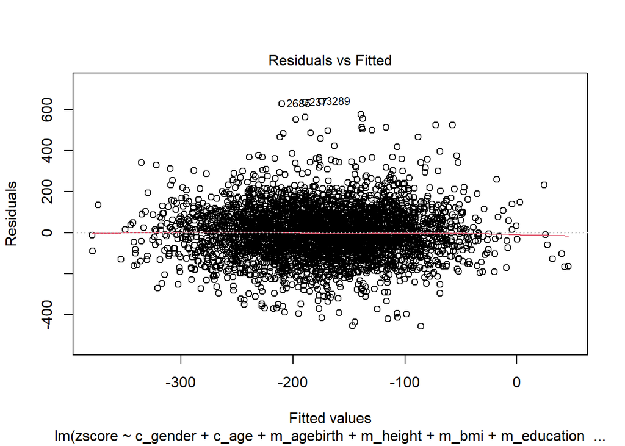

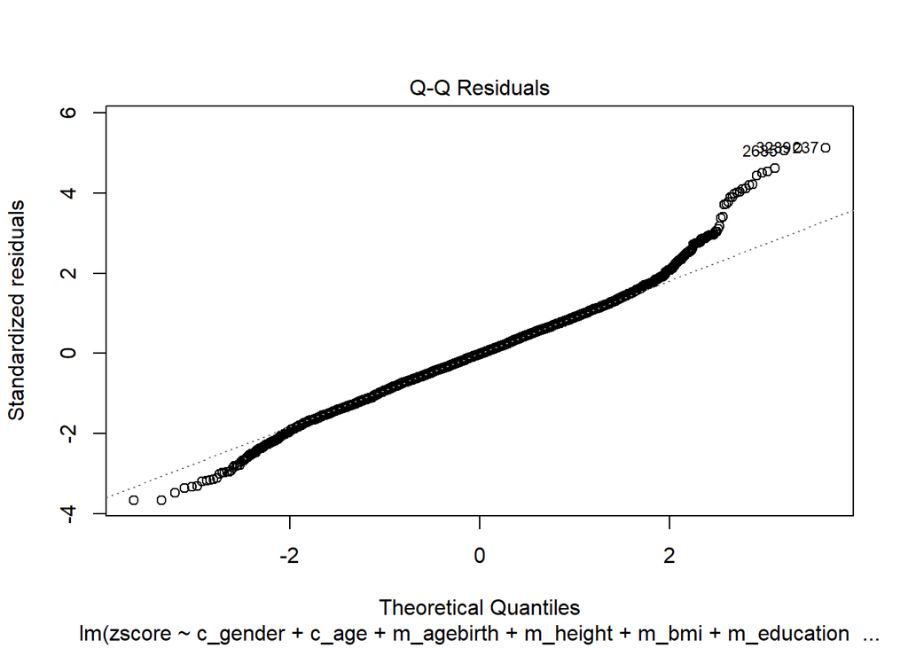

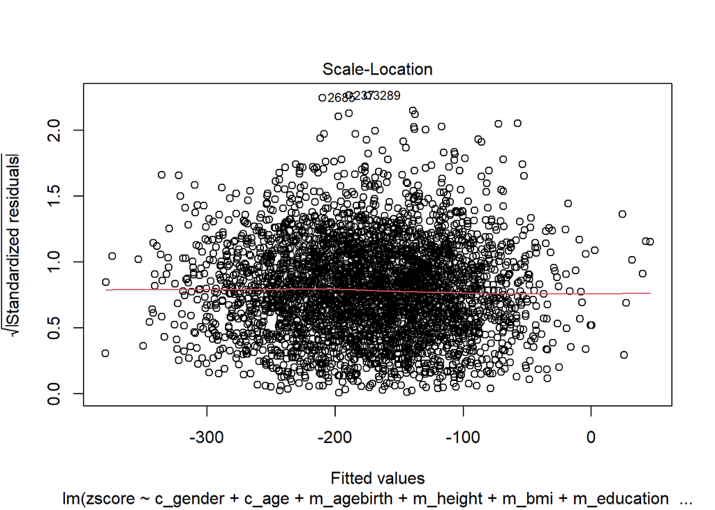

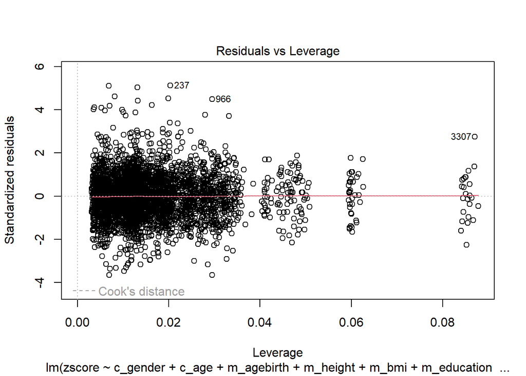

```r
plot(fit4)
```

```r
fit4_N <- lm
```

```r
fit5 <- lm(zscore ~ c_gender + c_age + m_agebirth + m_height + m_bmi + m_education + region, data = train_data2)
summary(fit5)
```

```
##
## Call:
## lm(formula = zscore ~ c_gender + c_age + m_agebirth + m_height +
##     m_bmi + m_education + region, data = train_data2)
##
## Residuals:
##     Min      1Q  Median      3Q     Max
## -446.05  -72.22   -1.19   72.07  677.19
##
## Coefficients:
##                Estimate Std. Error t value Pr(>|t|)
## (Intercept)  -1126.5983    75.9209 -14.839  < 2e-16 ***
## c_gender1      -10.6778     5.2782  -2.023 0.043193 *
## c_age           -0.4823     0.2215  -2.178 0.029531 *
## m_agebirth       1.3098     0.3991   3.282 0.001047 **
## m_height         5.3377     0.4489  11.890  < 2e-16 ***
## m_bmi            2.9610     0.8191   3.615 0.000307 ***
## m_education2    10.5500     7.2720   1.451 0.146985
## m_education3    36.7148     9.3536   3.925 8.93e-05 ***
## m_education4   123.0897    21.9465   5.609 2.29e-08 ***
## region2         11.3562    10.2861   1.104 0.269699
## region3        -23.8850    12.4156  -1.924 0.054508 .
## region4        -39.9290    12.5690  -3.177 0.001510 **
## region5          3.4832    11.2166   0.311 0.756179
## region6        -40.6624    12.1187  -3.355 0.000806 ***
## region7         -5.1765    15.1395  -0.342 0.732441
## region8         14.3836    10.9324   1.316 0.188414
## region9          5.8825    13.6816   0.430 0.667270
## ---
## Signif. codes:  0 '***' 0.001 '**' 0.01 '*' 0.05 '.' 0.1 ' ' 1
##
## Residual standard error: 124.1 on 2220 degrees of freedom
## Multiple R-squared:  0.1498, Adjusted R-squared:  0.1437
## F-statistic: 24.46 on 16 and 2220 DF,  p-value: < 2.2e-16
```

```r
predicted <- predict(fit5, test_data[test_data$c_breastf > 2,])
actual <- test_data[test_data$c_breastf > 2,]$zscore
rmse(predicted, actual)
```

```
## [1] 127.3721
```

```r
c(AIC(fit4), AIC(fit5))
```

```
## [1] 47036.87 27936.13
```

```r
fit6 <- lm(zscore ~ c_gender + c_age*c_breastf + m_agebirth + m_height + m_bmi + m_education + district, data = train_data2)
summary(fit6)
```

```
##
## Call:
## lm(formula = zscore ~ c_gender + c_age * c_breastf + m_agebirth +
##     m_height + m_bmi + m_education + district, data = train_data2)
##
## Residuals:
##     Min      1Q  Median      3Q     Max
## -458.97  -74.83   -2.39   72.96  667.81
##
## Coefficients:
##                   Estimate Std. Error t value Pr(>|t|)
## (Intercept)     -1.110e+03  8.518e+01 -13.027  < 2e-16 ***
## c_gender1       -1.132e+01  5.304e+00  -2.135 0.032885 *
## c_age           -1.601e+00  8.850e-01  -1.809 0.070577 .
## c_breastf       -3.367e+00  2.038e+00  -1.652 0.098753 .
## m_agebirth       1.429e+00  4.046e-01   3.530 0.000424 ***
## m_height         5.284e+00  4.557e-01  11.595  < 2e-16 ***
## m_bmi            2.778e+00  8.390e-01   3.311 0.000946 ***
## m_education2     9.742e+00  7.605e+00   1.281 0.200327
## m_education3     3.099e+01  9.822e+00   3.155 0.001625 **
## m_education4     1.207e+02  2.228e+01   5.418 6.69e-08 ***
## district13      -1.969e+00  2.555e+01  -0.077 0.938600
## district14       1.781e+01  3.040e+01   0.586 0.558163
## district15       2.293e+01  2.977e+01   0.770 0.441223
## district21      -9.905e+01  4.528e+01  -2.187 0.028817 *
## district22       3.128e+01  2.513e+01   1.245 0.213433
## district23       6.917e+01  3.025e+01   2.286 0.022331 *
## district24      -1.220e+01  3.697e+01  -0.330 0.741412
## district25      -1.671e+01  2.833e+01  -0.590 0.555382
## district26       4.011e+01  3.792e+01   1.058 0.290275
## district27       2.733e+01  2.712e+01   1.008 0.313714
## district28       4.809e+00  3.400e+01   0.141 0.887551
## district31       1.046e+01  2.478e+01   0.422 0.673126
## district32       2.541e+01  3.303e+01   0.769 0.441705
## district33      -2.984e+01  4.755e+01  -0.628 0.530287
## district34       6.886e+01  3.102e+01   2.219 0.026562 *
## district35       7.344e+00  2.812e+01   0.261 0.793952
## district36      -5.274e-01  2.674e+01  -0.020 0.984270
## district41       7.070e+01  2.971e+01   2.379 0.017427 *
## district42       4.958e+01  2.518e+01   1.969 0.049095 *
```

[output cut: 26 more lines]

```
## district91       4.871e+01  5.402e+01   0.902 0.367233
## district92       9.320e+01  3.182e+01   2.928 0.003442 **
## district93       8.288e+01  2.519e+01   3.290 0.001017 **
## district94       5.877e+01  2.283e+01   2.575 0.010096 *
## district95       5.540e+01  2.773e+01   1.998 0.045821 *
## district97       7.792e+01  2.285e+01   3.410 0.000662 ***
## district98       4.920e+01  2.047e+01   2.404 0.016315 *
## district99       6.632e+00  3.611e+01   0.184 0.854278
## c_age:c_breastf  6.568e-02  4.851e-02   1.354 0.175870
## ---
## Signif. codes:  0 '***' 0.001 '**' 0.01 '*' 0.05 '.' 0.1 ' ' 1
##
## Residual standard error: 123.5 on 2173 degrees of freedom
## Multiple R-squared:  0.1762, Adjusted R-squared:  0.1523
## F-statistic: 7.375 on 63 and 2173 DF,  p-value: < 2.2e-16
```

```r
predicted <- predict(fit6, test_data[test_data$c_breastf > 2,])
actual <- test_data[test_data$c_breastf > 2,]$zscore
rmse(predicted, actual)
```

```
## [1] 127.1197
```

```r
fit7 <- lm(zscore ~ c_gender + c_age*c_breastf + m_agebirth + m_height + m_bmi + m_education + region, data = train_data2)
summary(fit7)
```

```
##
## Call:
## lm(formula = zscore ~ c_gender + c_age * c_breastf + m_agebirth +
##     m_height + m_bmi + m_education + region, data = train_data2)
##
## Residuals:
##     Min      1Q  Median      3Q     Max
## -444.87  -72.30   -1.84   73.00  678.98
##
## Coefficients:
##                   Estimate Std. Error t value Pr(>|t|)
## (Intercept)     -1.074e+03  8.311e+01 -12.920  < 2e-16 ***
## c_gender1       -1.092e+01  5.279e+00  -2.069 0.038632 *
## c_age           -1.394e+00  8.826e-01  -1.580 0.114307
## c_breastf       -3.113e+00  2.029e+00  -1.534 0.125214
## m_agebirth       1.360e+00  4.005e-01   3.396 0.000696 ***
## m_height         5.328e+00  4.492e-01  11.862  < 2e-16 ***
## m_bmi            2.929e+00  8.190e-01   3.577 0.000356 ***
## m_education2     1.166e+01  7.294e+00   1.599 0.109898
## m_education3     3.703e+01  9.352e+00   3.960 7.74e-05 ***
## m_education4     1.221e+02  2.202e+01   5.544 3.30e-08 ***
## region2          1.129e+01  1.028e+01   1.098 0.272277
## region3         -2.002e+01  1.261e+01  -1.588 0.112496
## region4         -4.016e+01  1.256e+01  -3.197 0.001410 **
## region5          3.787e+00  1.123e+01   0.337 0.735895
## region6         -3.914e+01  1.218e+01  -3.215 0.001323 **
## region7         -4.039e+00  1.515e+01  -0.267 0.789808
## region8          1.630e+01  1.099e+01   1.483 0.138328
## region9          9.255e+00  1.387e+01   0.667 0.504678
## c_age:c_breastf  5.398e-02  4.836e-02   1.116 0.264473
## ---
## Signif. codes:  0 '***' 0.001 '**' 0.01 '*' 0.05 '.' 0.1 ' ' 1
##
## Residual standard error: 124 on 2218 degrees of freedom
## Multiple R-squared:  0.1513, Adjusted R-squared:  0.1444
## F-statistic: 21.96 on 18 and 2218 DF,  p-value: < 2.2e-16
```

```r
predicted <- predict(fit7, test_data[test_data$c_breastf > 2,])
actual <- test_data[test_data$c_breastf > 2,]$zscore
rmse(predicted, actual)
```

```
## [1] 127.7395
```

```r
c(AIC(fit4), AIC(fit5), AIC(fit6), AIC(fit7))
```

```
## [1] 47036.87 27936.13 27959.80 27936.39
```

fit5 is the best, also fit7 has a good AIC. fit6 has the lowest RMSE on the test set.

Now I try to perform the log-transformation of some skewed variables to see if I can improve the model

```r
train_data2$log_m_agebirth <- log(train_data2$m_agebirth)
train_data2$log_m_bmi <- log(train_data2$m_bmi)

test_data$log_m_agebirth <- log(test_data$m_agebirth)
test_data$log_m_bmi <- log(test_data$m_bmi)
```

```r
fit8 <- lm(zscore ~ c_gender + c_age + log_m_agebirth + m_height + log_m_bmi + m_education + region, data = train_data2)
summary(fit8)
```

```
##
## Call:
## lm(formula = zscore ~ c_gender + c_age + log_m_agebirth + m_height +
##     log_m_bmi + m_education + region, data = train_data2)
##
## Residuals:
##     Min      1Q  Median      3Q     Max
## -443.82  -73.09   -0.69   72.77  678.32
##
## Coefficients:
##                  Estimate Std. Error t value Pr(>|t|)
## (Intercept)    -1346.3124    99.1684 -13.576  < 2e-16 ***
## c_gender1        -10.6633     5.2797  -2.020 0.043537 *
## c_age             -0.4812     0.2215  -2.172 0.029954 *
## log_m_agebirth    33.7310    10.5491   3.198 0.001406 **
## m_height           5.3236     0.4489  11.859  < 2e-16 ***
## log_m_bmi         69.1330    19.1817   3.604 0.000320 ***
## m_education2       9.8464     7.2459   1.359 0.174319
## m_education3      35.8106     9.3201   3.842 0.000125 ***
## m_education4     122.2813    21.9525   5.570 2.85e-08 ***
## region2           11.3192    10.2879   1.100 0.271346
## region3          -23.9797    12.4167  -1.931 0.053579 .
## region4          -40.0163    12.5700  -3.183 0.001475 **
## region5            3.5138    11.2173   0.313 0.754120
## region6          -40.6933    12.1191  -3.358 0.000799 ***
## region7           -5.3066    15.1431  -0.350 0.726051
## region8           14.0840    10.9348   1.288 0.197880
## region9            5.8379    13.6891   0.426 0.669809
## ---
## Signif. codes:  0 '***' 0.001 '**' 0.01 '*' 0.05 '.' 0.1 ' ' 1
##
## Residual standard error: 124.1 on 2220 degrees of freedom
## Multiple R-squared:  0.1495, Adjusted R-squared:  0.1434
## F-statistic:  24.4 on 16 and 2220 DF,  p-value: < 2.2e-16
```

```r
predicted <- predict(fit8, test_data[test_data$c_breastf > 2,])
actual <- test_data[test_data$c_breastf > 2,]$zscore
rmse(predicted, actual)
```

```
## [1] 127.4566
```

```r
fit9 <- lm(zscore ~ c_gender + c_age*c_breastf + log_m_agebirth + m_height + log_m_bmi + m_education + region, data = train_data2)
summary(fit9)
```

```
##
## Call:
## lm(formula = zscore ~ c_gender + c_age * c_breastf + log_m_agebirth +
##     m_height + log_m_bmi + m_education + region, data = train_data2)
##
## Residuals:
##     Min      1Q  Median      3Q     Max
## -442.55  -72.36   -1.18   73.30  680.23
##
## Coefficients:
##                   Estimate Std. Error t value Pr(>|t|)
## (Intercept)     -1.295e+03  1.048e+02 -12.358  < 2e-16 ***
## c_gender1       -1.091e+01  5.280e+00  -2.067 0.038846 *
## c_age           -1.393e+00  8.828e-01  -1.578 0.114643
## c_breastf       -3.123e+00  2.030e+00  -1.539 0.123959
## log_m_agebirth   3.511e+01  1.059e+01   3.316 0.000927 ***
## m_height         5.314e+00  4.492e-01  11.829  < 2e-16 ***
## log_m_bmi        6.848e+01  1.918e+01   3.571 0.000363 ***
## m_education2     1.095e+01  7.267e+00   1.507 0.131845
## m_education3     3.610e+01  9.318e+00   3.874 0.000110 ***
## m_education4     1.212e+02  2.203e+01   5.503 4.17e-08 ***
## region2          1.124e+01  1.028e+01   1.093 0.274527
## region3         -2.008e+01  1.261e+01  -1.592 0.111571
## region4         -4.025e+01  1.257e+01  -3.203 0.001380 **
## region5          3.814e+00  1.123e+01   0.340 0.734139
## region6         -3.915e+01  1.218e+01  -3.215 0.001323 **
## region7         -4.158e+00  1.515e+01  -0.274 0.783832
## region8          1.601e+01  1.099e+01   1.456 0.145435
## region9          9.245e+00  1.388e+01   0.666 0.505350
## c_age:c_breastf  5.401e-02  4.837e-02   1.117 0.264271
## ---
## Signif. codes:  0 '***' 0.001 '**' 0.01 '*' 0.05 '.' 0.1 ' ' 1
##
## Residual standard error: 124.1 on 2218 degrees of freedom
## Multiple R-squared:  0.151,  Adjusted R-squared:  0.1441
## F-statistic: 21.91 on 18 and 2218 DF,  p-value: < 2.2e-16
```

```r
predicted <- predict(fit9, test_data[test_data$c_breastf > 2,])
actual <- test_data[test_data$c_breastf > 2,]$zscore
rmse(predicted, actual)
```

```
## [1] 127.8258
```

```r
c(AIC(fit4), AIC(fit5), AIC(fit6), AIC(fit7),  AIC(fit8), AIC(fit9))
```

```
## [1] 47036.87 27936.13 27959.80 27936.39 27936.92 27937.13
```

By using the log transformation I don’t notice any improvement in the model

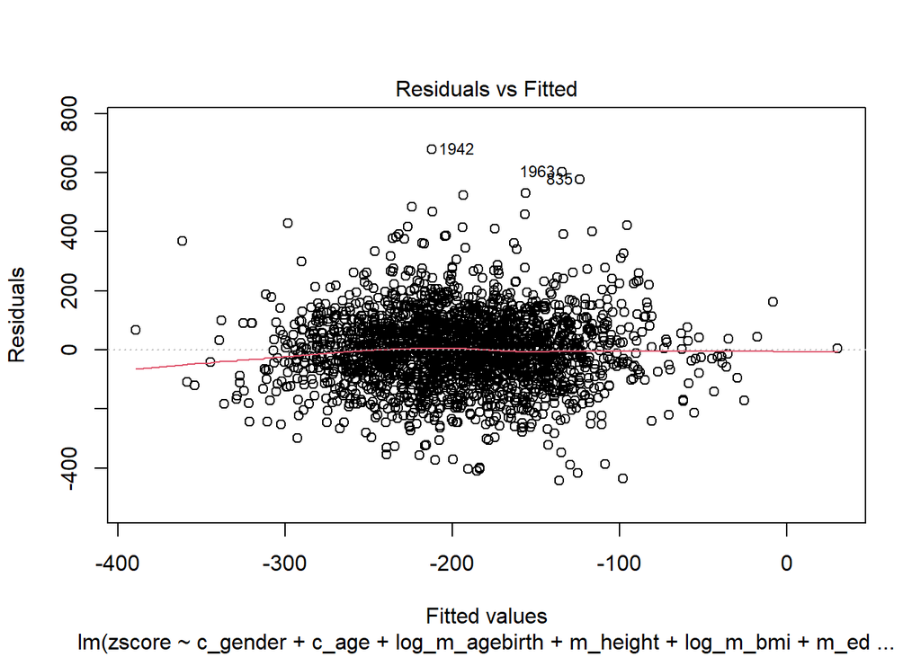

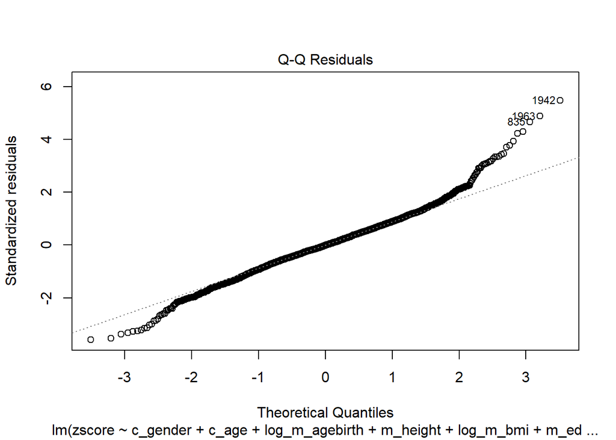

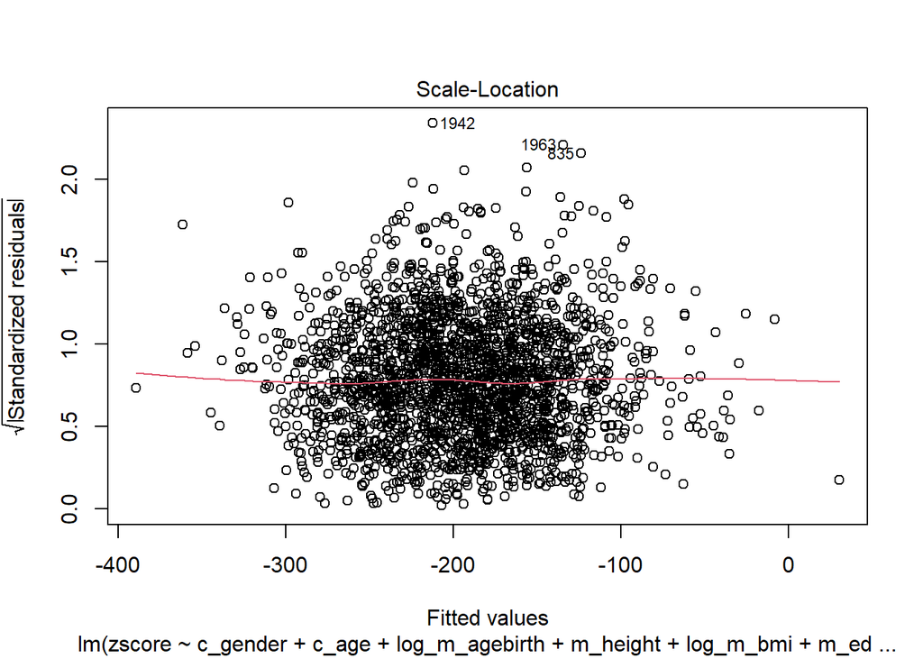

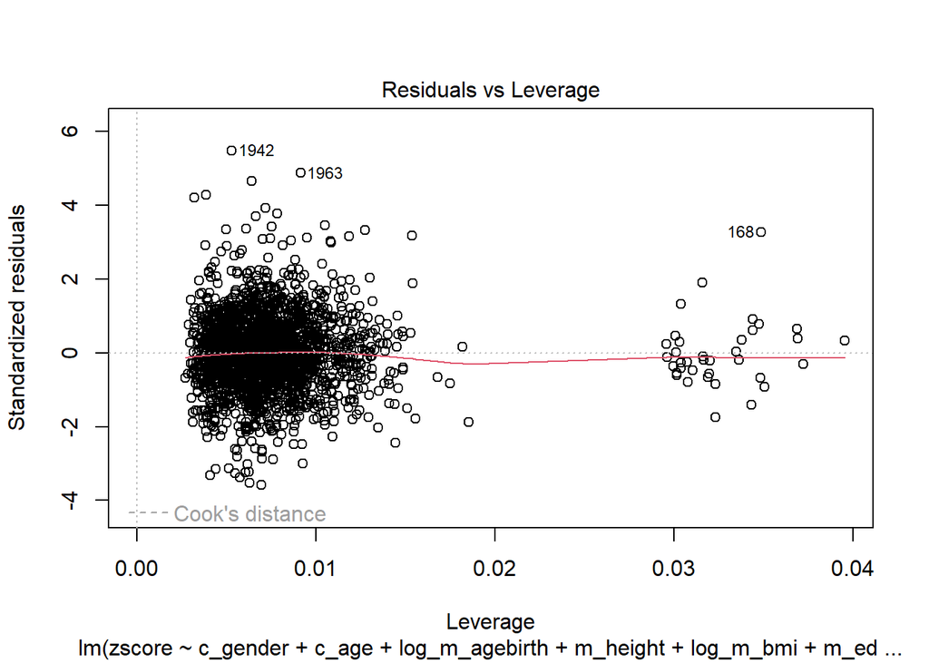

```r
plot(fit8)
```

**Standardizzare tutte le variabili numeriche**

# GAM

```r
library(PerformanceAnalytics)
library(mgcv)
gamfit0 <- gam(zscore ~ c_gender + s(c_breastf) + s(c_age) + s(m_agebirth) + s(m_height) + s(m_bmi) + m_education + m_work + region + district, data = train_data2)
summary(gamfit0)
```

```
##
## Family: gaussian
## Link function: identity
##
## Formula:
## zscore ~ c_gender + s(c_breastf) + s(c_age) + s(m_agebirth) +
##     s(m_height) + s(m_bmi) + m_education + m_work + region +
##     district
##
## Parametric coefficients:
##               Estimate Std. Error t value Pr(>|t|)
## (Intercept)  -191.5232     7.6604 -25.002  < 2e-16 ***
## c_gender1     -10.6395     5.2232  -2.037 0.041774 *
## m_education2    9.4893     7.5483   1.257 0.208836
## m_education3   30.4393     9.7266   3.129 0.001775 **
## m_education4  123.3714    22.0784   5.588 2.59e-08 ***
## m_work1        -1.5734     5.6505  -0.278 0.780695
## region2        -4.1476     6.9771  -0.594 0.552266
## region3       -22.7506     9.0756  -2.507 0.012256 *
## region4       -41.3741     8.6153  -4.802 1.68e-06 ***
## region5         3.6906     6.2495   0.591 0.554889
## region6       -58.6646    17.5962  -3.334 0.000871 ***
## region7       -15.7713    11.1451  -1.415 0.157186
## region8        -0.2877     8.6438  -0.033 0.973455
## region9         7.5415     9.9583   0.757 0.448950
## district13    -19.9726    16.1719  -1.235 0.216958
## district14     20.6299    29.9831   0.688 0.491495
## district15      3.4225    20.2860   0.169 0.866040
## district21    -85.4117    44.6490  -1.913 0.055886 .
## district22     29.8446    24.7568   1.206 0.228137
## district23     68.8572    29.8505   2.307 0.021164 *
## district24    -27.9633    26.8736  -1.041 0.298201
## district25    -13.6200    27.8947  -0.488 0.625412
## district26      3.6126    28.8502   0.125 0.900362
## district27      8.8395    17.8614   0.495 0.620726
## district28      1.0391    33.5646   0.031 0.975305
## district31     -5.7002    15.3570  -0.371 0.710542
## district32    -11.3312    25.3051  -0.448 0.654356
## district33    -34.6308    46.7549  -0.741 0.458963
## district34     19.1105    23.5393   0.812 0.416964
```

[output cut: 39 more lines]

```
## Signif. codes:  0 '***' 0.001 '**' 0.01 '*' 0.05 '.' 0.1 ' ' 1
##
## Approximate significance of smooth terms:
##                 edf Ref.df      F  p-value
## s(c_breastf)  6.651  7.644  2.139  0.04762 *
## s(c_age)      8.767  8.973  9.243  < 2e-16 ***
## s(m_agebirth) 1.000  1.000 15.479 8.64e-05 ***
## s(m_height)   1.690  2.152 65.365  < 2e-16 ***
## s(m_bmi)      1.000  1.000  8.015  0.00468 **
## ---
## Signif. codes:  0 '***' 0.001 '**' 0.01 '*' 0.05 '.' 0.1 ' ' 1
##
## Rank: 104/112
## R-sq.(adj) =  0.183   Deviance explained = 21.1%
## GCV =  15216  Scale est. = 14684     n = 2237
```

I can remove the variable m_work because it is not significant and make m_agebirth, m_height and m_bmi as linear variables

```r
predicted <- predict(gamfit0, test_data[test_data$c_breastf > 2,])
actual <- test_data[test_data$c_breastf > 2,]$zscore
rmse(predicted, actual)
```

```
## [1] 124.4992
```

```r
gamfit1 <- gam(zscore ~ c_gender + s(c_breastf) + s(c_age) + m_agebirth + m_height + m_bmi + m_education + region + district, data = train_data2)
summary(gamfit1)
```

```
##
## Family: gaussian
## Link function: identity
##
## Formula:
## zscore ~ c_gender + s(c_breastf) + s(c_age) + m_agebirth + m_height +
##     m_bmi + m_education + region + district
##
## Parametric coefficients:
##                Estimate Std. Error t value Pr(>|t|)
## (Intercept)  -1050.4137    69.0865 -15.204  < 2e-16 ***
## c_gender1      -10.6084     5.2223  -2.031  0.04234 *
## m_agebirth       1.5674     0.4007   3.912 9.44e-05 ***
## m_height         5.2942     0.4482  11.811  < 2e-16 ***
## m_bmi            2.3498     0.8284   2.836  0.00460 **
## m_education2     9.5250     7.5243   1.266  0.20569
## m_education3    30.4891     9.6705   3.153  0.00164 **
## m_education4   123.0904    21.8886   5.623 2.11e-08 ***
## region2        -68.4411     9.0246  -7.584 4.95e-14 ***
## region3        -84.6504    10.1668  -8.326  < 2e-16 ***
## region4       -102.0489     9.0849 -11.233  < 2e-16 ***
## region5        -44.5760     7.4811  -5.958 2.97e-09 ***
## region6       -131.7048    18.2675  -7.210 7.71e-13 ***
## region7        -77.8999    11.8606  -6.568 6.37e-11 ***
## region8        -64.6176    10.5323  -6.135 1.01e-09 ***
## region9        -54.4849    11.2693  -4.835 1.43e-06 ***
## district13     -32.1961    16.1709  -1.991  0.04661 *
## district14      20.3331    29.9716   0.678  0.49758
## district15      -9.4843    20.2157  -0.469  0.63901
## district21     -85.2555    44.6491  -1.909  0.05634 .
## district22      30.2178    24.7299   1.222  0.22187
## district23      69.4689    29.8412   2.328  0.02001 *
## district24     -40.2030    26.8702  -1.496  0.13475
## district25     -13.2474    27.8888  -0.475  0.63483
## district26      -7.5690    28.7593  -0.263  0.79243
## district27      -2.6285    17.9137  -0.147  0.88336
## district28       1.4735    33.5606   0.044  0.96498
## district31     -17.5370    15.3703  -1.141  0.25401
## district32     -22.7399    25.2127  -0.902  0.36720
## district33     -35.2825    46.7423  -0.755  0.45043
```

[output cut: 37 more lines]

```
## district98     -37.1665     7.9949  -4.649 3.54e-06 ***
## district99     -54.8332    28.1387  -1.949  0.05146 .
## ---
## Signif. codes:  0 '***' 0.001 '**' 0.01 '*' 0.05 '.' 0.1 ' ' 1
##
## Approximate significance of smooth terms:
##                edf Ref.df     F p-value
## s(c_breastf) 6.634  7.631 2.152  0.0465 *
## s(c_age)     8.708  8.956 9.001  <2e-16 ***
## ---
## Signif. codes:  0 '***' 0.001 '**' 0.01 '*' 0.05 '.' 0.1 ' ' 1
##
## Rank: 79/87
## R-sq.(adj) =  0.183   Deviance explained = 21.1%
## GCV =  15206  Scale est. = 14687     n = 2237
```

```r
predicted <- predict(gamfit1, test_data[test_data$c_breastf > 2,])
actual <- test_data[test_data$c_breastf > 2,]$zscore
rmse(predicted, actual)
```

```
## [1] 124.5365
```

I try with the log variables

```r
gamfit2 <- gam(zscore ~ c_gender + s(c_breastf) + s(c_age) + log_m_agebirth + m_height + log_m_bmi + m_education + region + district, data = train_data2)
summary(gamfit2)
```

```
##
## Family: gaussian
## Link function: identity
##
## Formula:
## zscore ~ c_gender + s(c_breastf) + s(c_age) + log_m_agebirth +
##     m_height + log_m_bmi + m_education + region + district
##
## Parametric coefficients:
##                  Estimate Std. Error t value Pr(>|t|)
## (Intercept)    -1239.5288    91.1391 -13.600  < 2e-16 ***
## c_gender1        -10.5919     5.2238  -2.028 0.042722 *
## log_m_agebirth    40.5779    10.5941   3.830 0.000132 ***
## m_height           5.2794     0.4483  11.776  < 2e-16 ***
## log_m_bmi         55.0733    19.4277   2.835 0.004628 **
## m_education2       8.7683     7.5000   1.169 0.242490
## m_education3      29.5057     9.6383   3.061 0.002231 **
## m_education4     122.1564    21.8960   5.579 2.72e-08 ***
## region2          -82.6487    10.2321  -8.077 1.09e-15 ***
## region3          -98.3724    10.9678  -8.969  < 2e-16 ***
## region4         -115.3900     9.8925 -11.664  < 2e-16 ***
## region5          -55.1199     8.2126  -6.712 2.45e-11 ***
## region6         -148.1028    18.9515  -7.815 8.52e-15 ***
## region7          -91.5783    12.3821  -7.396 2.00e-13 ***
## region8          -78.8320    11.6241  -6.782 1.53e-11 ***
## region9          -68.1441    11.8557  -5.748 1.03e-08 ***
## district13       -34.4438    16.1709  -2.130 0.033285 *
## district14        20.9489    29.9809   0.699 0.484789
## district15       -12.3507    20.2386  -0.610 0.541756
## district21       -84.3863    44.6594  -1.890 0.058952 .
## district22        31.2943    24.7352   1.265 0.205945
## district23        70.4067    29.8542   2.358 0.018445 *
## district24       -43.2530    26.9058  -1.608 0.108075
## district25       -13.2356    27.8943  -0.474 0.635197
## district26        -9.8289    28.7685  -0.342 0.732643
## district27        -5.0616    17.9376  -0.282 0.777832
## district28         1.9142    33.5685   0.057 0.954531
## district31       -20.2808    15.3836  -1.318 0.187530
## district32       -24.5668    25.2172  -0.974 0.330062
## district33       -35.0513    46.7535  -0.750 0.453514
```

[output cut: 37 more lines]

```
## district98       -42.6522     8.3098  -5.133 3.11e-07 ***
## district99       -56.7166    28.1539  -2.015 0.044078 *
## ---
## Signif. codes:  0 '***' 0.001 '**' 0.01 '*' 0.05 '.' 0.1 ' ' 1
##
## Approximate significance of smooth terms:
##                edf Ref.df     F p-value
## s(c_breastf) 6.632  7.629 2.130  0.0491 *
## s(c_age)     8.708  8.956 8.992  <2e-16 ***
## ---
## Signif. codes:  0 '***' 0.001 '**' 0.01 '*' 0.05 '.' 0.1 ' ' 1
##
## Rank: 79/87
## R-sq.(adj) =  0.183   Deviance explained =   21%
## GCV =  15212  Scale est. = 14692     n = 2237
```

```r
predicted <- predict(gamfit2, test_data[test_data$c_breastf > 2,])
actual <- test_data[test_data$c_breastf > 2,]$zscore
rmse(predicted, actual)
```

```
## [1] 124.6188
```

```r
gamfit3 <- gam(zscore ~ c_gender + s(c_breastf) + s(c_age) + log_m_agebirth + m_height + log_m_bmi + m_education + district, data = train_data2)
summary(gamfit3)
```

```
##
## Family: gaussian
## Link function: identity
##
## Formula:
## zscore ~ c_gender + s(c_breastf) + s(c_age) + log_m_agebirth +
##     m_height + log_m_bmi + m_education + district
##
## Parametric coefficients:
##                  Estimate Std. Error t value Pr(>|t|)
## (Intercept)    -1387.6316   100.1490 -13.856  < 2e-16 ***
## c_gender1        -10.5919     5.2238  -2.028 0.042722 *
## log_m_agebirth    40.5779    10.5941   3.830 0.000132 ***
## m_height           5.2794     0.4483  11.776  < 2e-16 ***
## log_m_bmi         55.0733    19.4277   2.835 0.004628 **
## m_education2       8.7683     7.5000   1.169 0.242490
## m_education3      29.5057     9.6383   3.061 0.002231 **
## m_education4     122.1564    21.8960   5.579 2.72e-08 ***
## district13        -1.7311    25.2604  -0.069 0.945370
## district14        20.9489    29.9809   0.699 0.484789
## district15        20.3620    29.3385   0.694 0.487733
## district21       -84.3863    44.6594  -1.890 0.058952 .
## district22        31.2943    24.7352   1.265 0.205945
## district23        70.4067    29.8542   2.358 0.018445 *
## district24       -10.5403    36.4261  -0.289 0.772333
## district25       -13.2356    27.8943  -0.474 0.635197
## district26        39.9014    37.3374   1.069 0.285337
## district27        27.6511    26.7723   1.033 0.301802
## district28         1.9142    33.5685   0.057 0.954531
## district31        12.4319    24.4039   0.509 0.610507
## district32        31.9577    32.5564   0.982 0.326402
## district33       -35.0513    46.7535  -0.750 0.453514
## district34        63.1861    30.5541   2.068 0.038758 *
## district35         8.2468    27.9183   0.295 0.767725
## district36        -4.7663    26.3993  -0.181 0.856742
## district41        68.4684    29.2825   2.338 0.019467 *
## district42        45.8745    24.8190   1.848 0.064686 .
## district43        29.6905    32.8723   0.903 0.366516
## district44        53.6840    23.7416   2.261 0.023847 *
## district45        51.8766    31.8264   1.630 0.103249
```

[output cut: 28 more lines]

```
## district97        75.1267    22.5231   3.336 0.000866 ***
## district98        50.3307    20.1667   2.496 0.012644 *
## district99        12.5542    35.6135   0.353 0.724489
## ---
## Signif. codes:  0 '***' 0.001 '**' 0.01 '*' 0.05 '.' 0.1 ' ' 1
##
## Approximate significance of smooth terms:
##                edf Ref.df     F p-value
## s(c_breastf) 6.632  7.629 2.130  0.0491 *
## s(c_age)     8.708  8.956 8.992  <2e-16 ***
## ---
## Signif. codes:  0 '***' 0.001 '**' 0.01 '*' 0.05 '.' 0.1 ' ' 1
##
## R-sq.(adj) =  0.183   Deviance explained =   21%
## GCV =  15212  Scale est. = 14692     n = 2237
```

```r
predicted <- predict(gamfit3, test_data[test_data$c_breastf > 2,])
actual <- test_data[test_data$c_breastf > 2,]$zscore
rmse(predicted, actual)
```

```
## [1] 124.6188
```

```r
gamfit4 <- gam(zscore ~ c_gender + s(c_breastf) + s(c_age) + log_m_agebirth + m_height + log_m_bmi + m_education + region, data = train_data2)
summary(gamfit4)
```

```
##
## Family: gaussian
## Link function: identity
##
## Formula:
## zscore ~ c_gender + s(c_breastf) + s(c_age) + log_m_agebirth +
##     m_height + log_m_bmi + m_education + region
##
## Parametric coefficients:
##                  Estimate Std. Error t value Pr(>|t|)
## (Intercept)    -1347.1769    97.4769 -13.820  < 2e-16 ***
## c_gender1        -10.3477     5.1959  -1.992 0.046546 *
## log_m_agebirth    38.3886    10.4745   3.665 0.000253 ***
## m_height           5.3113     0.4418  12.021  < 2e-16 ***
## log_m_bmi         57.9790    18.9415   3.061 0.002233 **
## m_education2      10.0483     7.1931   1.397 0.162574
## m_education3      34.9877     9.1785   3.812 0.000142 ***
## m_education4     123.9874    21.6359   5.731 1.14e-08 ***
## region2           12.1071    10.1137   1.197 0.231397
## region3          -15.8922    12.5453  -1.267 0.205366
## region4          -38.2525    12.3667  -3.093 0.002005 **
## region5            6.3097    11.0725   0.570 0.568836
## region6          -36.3278    12.0175  -3.023 0.002532 **
## region7            0.2617    14.9947   0.017 0.986077
## region8           17.6125    10.8307   1.626 0.104057
## region9           21.1257    13.8842   1.522 0.128263
## ---
## Signif. codes:  0 '***' 0.001 '**' 0.01 '*' 0.05 '.' 0.1 ' ' 1
##
## Approximate significance of smooth terms:
##                edf Ref.df     F p-value
## s(c_breastf) 6.809  7.773 2.480  0.0188 *
## s(c_age)     8.672  8.945 9.024  <2e-16 ***
## ---
## Signif. codes:  0 '***' 0.001 '**' 0.01 '*' 0.05 '.' 0.1 ' ' 1
##
## R-sq.(adj) =  0.176   Deviance explained = 18.7%
## GCV =  15034  Scale est. = 14823     n = 2237
```

```r
predicted <- predict(gamfit4, test_data[test_data$c_breastf > 2,])
actual <- test_data[test_data$c_breastf > 2,]$zscore
rmse(predicted, actual)
```

```
## [1] 124.6661
```

```r
c(AIC(gamfit1), AIC(gamfit2), AIC(gamfit3), AIC(gamfit4))
```

```
## [1] 27888.68 27889.55 27889.55 27865.58
```

gamfit4 has the best AIC, but it has a lower value of deviance explained. gamfit0 has the lowest RMSE on the test set.

Since all the models that have been tried so far give similar results, let’s try Trees and Random Forests

```r
library(tree)
t0 <- tree(zscore ~ . -district, data = train_data) # District cannot be used because it has too many levels
summary(t0)
```

```
##
## Regression tree:
## tree(formula = zscore ~ . - district, data = train_data)
## Variables actually used in tree construction:
## [1] "c_age"       "m_height"    "region"      "m_education"
## Number of terminal nodes:  5
## Residual mean deviance:  15720 = 58970000 / 3752
## Distribution of residuals:
##     Min.  1st Qu.   Median     Mean  3rd Qu.     Max.
## -421.500  -73.560   -1.409    0.000   73.590  671.600
```

```r
predicted <- predict(t0, test_data)
actual <- test_data$zscore
rmse(predicted, actual)
```

```
## [1] 132.7778
```

```r
library(randomForest)
rf0 <- randomForest(zscore ~ . - district, data = train_data) # District cannot be used because it has too many levels
summary(rf0)
```

```
##                 Length Class  Mode
## call               3   -none- call
## type               1   -none- character
## predicted       3757   -none- numeric
## mse              500   -none- numeric
## rsq              500   -none- numeric
## oob.times       3757   -none- numeric
## importance         9   -none- numeric
## importanceSD       0   -none- NULL
## localImportance    0   -none- NULL
## proximity          0   -none- NULL
## ntree              1   -none- numeric
## mtry               1   -none- numeric
## forest            11   -none- list
## coefs              0   -none- NULL
## y               3757   -none- numeric
## test               0   -none- NULL
## inbag              0   -none- NULL
## terms              3   terms  call
```

```r
predicted <- predict(rf0, test_data)
actual <- test_data$zscore
rmse(predicted, actual)
```

```
## [1] 123.2572
```

Since the tree didn’t give interesting results, let’s try to improve the Random Forest.

```r
rf1 <- randomForest(zscore ~ . - district - m_work, data = train_data) # District cannot be used because it has too many levels
summary(rf1)
```

```
##                 Length Class  Mode
## call               3   -none- call
## type               1   -none- character
## predicted       3757   -none- numeric
## mse              500   -none- numeric
## rsq              500   -none- numeric
## oob.times       3757   -none- numeric
## importance         8   -none- numeric
## importanceSD       0   -none- NULL
## localImportance    0   -none- NULL
## proximity          0   -none- NULL
## ntree              1   -none- numeric
## mtry               1   -none- numeric
## forest            11   -none- list
## coefs              0   -none- NULL
## y               3757   -none- numeric
## test               0   -none- NULL
## inbag              0   -none- NULL
## terms              3   terms  call
```

```r
predicted <- predict(rf1, test_data)
actual <- test_data$zscore
rmse(predicted, actual)
```

```
## [1] 122.868
```

```r
rf2 <- randomForest(zscore ~ . - district - m_work - c_breastf, data = train_data) # District cannot be used because it has too many levels
summary(rf2)
```

```
##                 Length Class  Mode
## call               3   -none- call
## type               1   -none- character
## predicted       3757   -none- numeric
## mse              500   -none- numeric
## rsq              500   -none- numeric
## oob.times       3757   -none- numeric
## importance         7   -none- numeric
## importanceSD       0   -none- NULL
## localImportance    0   -none- NULL
## proximity          0   -none- NULL
## ntree              1   -none- numeric
## mtry               1   -none- numeric
## forest            11   -none- list
## coefs              0   -none- NULL
## y               3757   -none- numeric
## test               0   -none- NULL
## inbag              0   -none- NULL
## terms              3   terms  call
```

```r
predicted <- predict(rf2, test_data)
actual <- test_data$zscore
rmse(predicted, actual)
```

```
## [1] 124.3568
```

```r
rf3 <- randomForest(zscore ~ . - district - m_work, data = train_data3) # District cannot be used because it has too many levels
summary(rf3)
```

```
##                 Length Class  Mode
## call               3   -none- call
## type               1   -none- character
## predicted       3757   -none- numeric
## mse              500   -none- numeric
## rsq              500   -none- numeric
## oob.times       3757   -none- numeric
## importance         8   -none- numeric
## importanceSD       0   -none- NULL
## localImportance    0   -none- NULL
## proximity          0   -none- NULL
## ntree              1   -none- numeric
## mtry               1   -none- numeric
## forest            11   -none- list
## coefs              0   -none- NULL
## y               3757   -none- numeric
## test               0   -none- NULL
## inbag              0   -none- NULL
## terms              3   terms  call
```